# Project: Automobile Data Analysis and Modeling (Part 2)

# Part 2: Exploratory Data Analysis

Exploratory Data Analysis (EDA) is the process of analyzing and visualizing data to uncover patterns, relationships, and insights. It helps you understand the dataset's structure, identify anomalies, and form hypotheses for further analysis.

In EDA, we use:

- **Statistics**: To summarize data (e.g., mean, median, variance).
- **Visualizations**: Charts and graphs like histograms, scatter plots, and heatmaps to explore relationships and trends.

EDA is an essential first step in any data analysis project to ensure data quality and guide decision-making.

```python
# Define required imports
import pandas as pd
pd.options.mode.copy_on_write = True

import numpy as np
import matplotlib.pyplot as plt
import seaborn as sns
%matplotlib inline
```

You can download the cleaned outomobile dataset from my GitHub repository using `requests`

```python
import requests

# URL of the raw file
url = "https://raw.githubusercontent.com/durdiev15/machine-learning/main/data-science-project/clean_automobile_df.csv"
# Download the file
response = requests.get(url)
# Save the file locally
with open("clean_automobile_df.csv", "wb") as file:
    file.write(response.content)

print("File downloaded as clean_automobile_df.csv")
```

```
File downloaded as clean_automobile_df.csv
```

```python
# Read data
df = pd.read_csv("clean_automobile_df.csv")
df.head(5)
```

|  | Unnamed: 0 | symboling | normalized-losses | make | num-of-doors | body-style | drive-wheels | engine-location | wheel-base | length | ... | city-mpg | highway-mpg | price | city-L/100km | highway-L/100km | horsepower-binned | fuel-type-diesel | fuel-type-gas | aspiration-std | aspiration-turbo |
| --- | --- | --- | --- | --- | --- | --- | --- | --- | --- | --- | --- | --- | --- | --- | --- | --- | --- | --- | --- | --- | --- |
| 0 | 0 | 3 | 122.0 | alfa-romero | two | convertible | rwd | front | 88.6 | 0.811148 | ... | 21 | 27 | 13495 | 11.190476 | 8.703704 | Low | 0 | 1 | 1 | 0 |
| 1 | 1 | 3 | 122.0 | alfa-romero | two | convertible | rwd | front | 88.6 | 0.811148 | ... | 21 | 27 | 16500 | 11.190476 | 8.703704 | Low | 0 | 1 | 1 | 0 |
| 2 | 2 | 1 | 122.0 | alfa-romero | two | hatchback | rwd | front | 94.5 | 0.822681 | ... | 19 | 26 | 16500 | 12.368421 | 9.038462 | Medium | 0 | 1 | 1 | 0 |
| 3 | 3 | 2 | 164.0 | audi | four | sedan | fwd | front | 99.8 | 0.848630 | ... | 24 | 30 | 13950 | 9.791667 | 7.833333 | Low | 0 | 1 | 1 | 0 |
| 4 | 4 | 2 | 164.0 | audi | four | sedan | 4wd | front | 99.4 | 0.848630 | ... | 18 | 22 | 17450 | 13.055556 | 10.681818 | Low | 0 | 1 | 1 | 0 |

5 rows × 32 columns

## Understanding Data Relationships

We analyze here how different variables in our dataset interact with one another. This process helps identify patterns, trends, and correlations that provide insights into the data's structure and behavior. For example, exploring relationships can reveal whether an increase in one variable (e.g., engine size) is associated with an increase or decrease in another (e.g., fuel efficiency). These insights are crucial for making informed decisions and building predictive models.

### Correlations

We aim to identify which variables play a key role in predicting the price. To achieve this, let's visualize the relationship between price and each other variable in the dataset. This will help us assess whether they are strong predictors.

```
(0.0, 53399.81831041754)
```

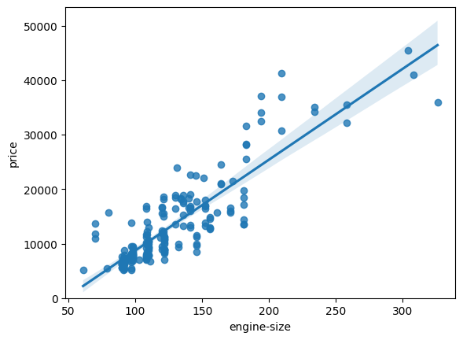

```python
# Engine size as potential predictor variable of price
sns.regplot(x="engine-size", y="price", data=df) # Positive Linear Relationship
plt.ylim(0,)
```

```python
df[["engine-size", "price"]].corr()
```

|  | engine-size | price |
| --- | --- | --- |
| engine-size | 1.000000 | 0.872335 |
| price | 0.872335 | 1.000000 |

As the engine size increases, the price also increases, indicating a strong positive correlation between these two variables. Engine size appears to be a good predictor of price, as the regression line closely resembles a diagonal line, showing a consistent trend.

When examining the correlation between `engine-size` and `price`, we find that it is approximately 0.87, further confirming the strength of their relationship.

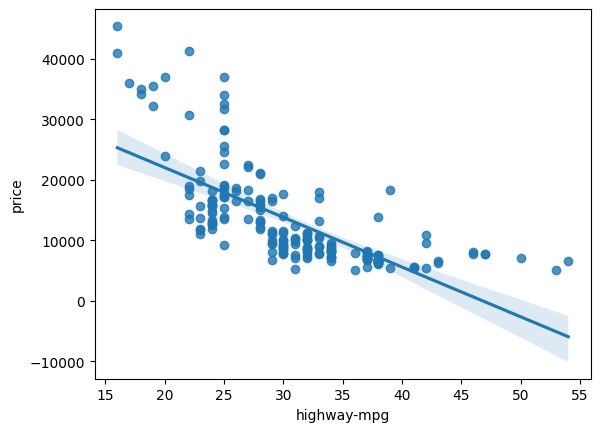

```python
# Highway mpg is a potential predictor variable of price. Let's find the scatterplot of "highway-mpg" and "price".
sns.regplot(x="highway-mpg", y="price", data=df)
```

```python
df[['highway-mpg', 'price']].corr()
```

|  | highway-mpg | price |
| --- | --- | --- |
| highway-mpg | 1.000000 | -0.704692 |
| price | -0.704692 | 1.000000 |

As highway-mpg increases, the price decreases, indicating a negative (inverse) relationship between these two variables. This suggests that highway-mpg could be a potential predictor of price.

The correlation between `highway-mpg` and `price` is approximately `-0.704`.

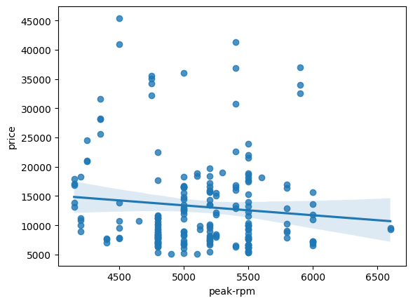

```python
# Let's see if "peak-rpm" is a predictor variable of "price".
sns.regplot(x="peak-rpm", y="price", data=df)
```

```python
df[['peak-rpm','price']].corr()
```

|  | peak-rpm | price |
| --- | --- | --- |
| peak-rpm | 1.000000 | -0.101616 |
| price | -0.101616 | 1.000000 |

Peak RPM does not appear to be a good predictor of price. The regression line is nearly horizontal, and the data points are highly scattered with significant variability. This makes it an unreliable variable for prediction.

Examining the correlation between `peak-rpm` and `price` confirms this, with a value of approximately `-0.1016`.

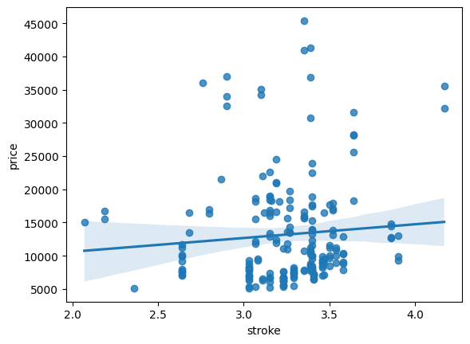

```python
#There is a weak correlation between the variable 'stroke' and 'price.' as such regression will not work well.
# We can see this using "regplot" to demonstrate this.
sns.regplot(x="stroke", y="price", data=df)
```

```python
df[["stroke","price"]].corr()
```

|  | stroke | price |
| --- | --- | --- |
| stroke | 1.000000 | 0.082269 |
| price | 0.082269 | 1.000000 |

### Categorical Statistical Analysis

Categorical variables are those that describe a characteristic or attribute of a data unit and are selected from a finite set of categories. These variables can be of type `object` or `int64`. A common and effective way to visualize categorical variables is through the use of boxplots, which provide insights into the distribution and relationship between categorical and numerical data.

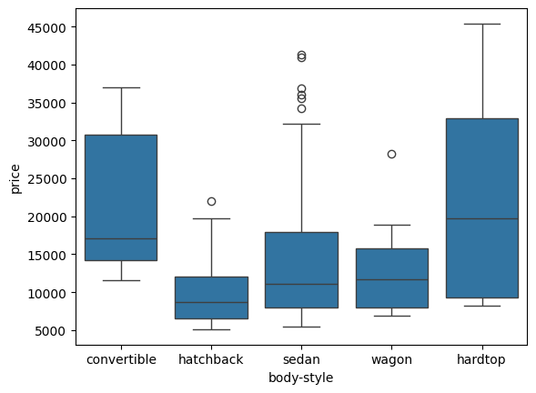

```python
# Let's look at the relationship between "body-style" and "price".
sns.boxplot(x="body-style", y="price", data=df)
```

We observe that the distributions of price across different `body-style` categories exhibit significant overlap, indicating that `body-style` may not be a reliable predictor of price. Next, let’s analyze the relationship between `engine-location` and `price`

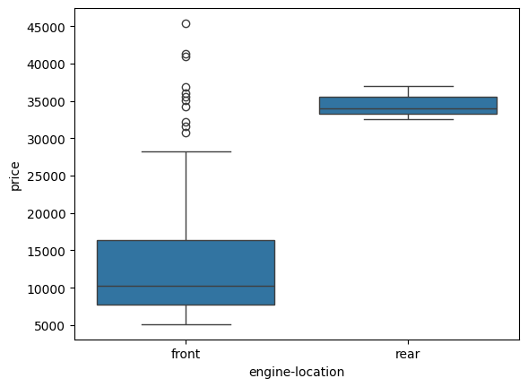

```python
sns.boxplot(x="engine-location", y="price", data=df)
```

Here we see that the distribution of price between these two engine-location categories, front and rear, are distinct enough to take engine-location as a potential good predictor of price.

Let's examine `drive-wheels` and `price`.

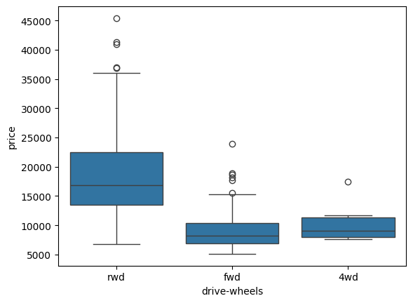

```python
# drive-wheels
sns.boxplot(x="drive-wheels", y="price", data=df)
```

Here we see that the distribution of price between the different drive-wheels categories differs. As such, drive-wheels could potentially be a predictor of price.

### Descriptive Statistical Analysis

Let's start by examining the variables using the `describe` method.

The `describe` function computes basic statistics for all continuous variables, automatically skipping any `NaN` values. It provides the following information:

- Count of the variable
- Mean
- Standard deviation (std)
- Minimum value
- Interquartile range (IQR: 25%, 50%, and 75%)
- Maximum value

```python
# We can apply the method "describe"
df.describe()
```

|  | Unnamed: 0 | symboling | normalized-losses | wheel-base | length | width | height | curb-weight | engine-size | bore | ... | peak-rpm | city-mpg | highway-mpg | price | city-L/100km | highway-L/100km | fuel-type-diesel | fuel-type-gas | aspiration-std | aspiration-turbo |
| --- | --- | --- | --- | --- | --- | --- | --- | --- | --- | --- | --- | --- | --- | --- | --- | --- | --- | --- | --- | --- | --- |
| count | 201.000000 | 201.000000 | 201.00000 | 201.000000 | 201.000000 | 201.000000 | 201.000000 | 201.000000 | 201.000000 | 201.000000 | ... | 201.000000 | 201.000000 | 201.000000 | 201.000000 | 201.000000 | 201.000000 | 201.000000 | 201.000000 | 201.000000 | 201.000000 |
| mean | 100.000000 | 0.840796 | 122.00000 | 98.797015 | 0.837102 | 0.915126 | 0.899108 | 2555.666667 | 126.875622 | 3.330692 | ... | 5117.665368 | 25.179104 | 30.686567 | 13207.129353 | 9.944145 | 8.044957 | 0.099502 | 0.900498 | 0.820896 | 0.179104 |
| std | 58.167861 | 1.254802 | 31.99625 | 6.066366 | 0.059213 | 0.029187 | 0.040933 | 517.296727 | 41.546834 | 0.268072 | ... | 478.113805 | 6.423220 | 6.815150 | 7947.066342 | 2.534599 | 1.840739 | 0.300083 | 0.300083 | 0.384397 | 0.384397 |
| min | 0.000000 | -2.000000 | 65.00000 | 86.600000 | 0.678039 | 0.837500 | 0.799331 | 1488.000000 | 61.000000 | 2.540000 | ... | 4150.000000 | 13.000000 | 16.000000 | 5118.000000 | 4.795918 | 4.351852 | 0.000000 | 0.000000 | 0.000000 | 0.000000 |
| 25% | 50.000000 | 0.000000 | 101.00000 | 94.500000 | 0.801538 | 0.890278 | 0.869565 | 2169.000000 | 98.000000 | 3.150000 | ... | 4800.000000 | 19.000000 | 25.000000 | 7775.000000 | 7.833333 | 6.911765 | 0.000000 | 1.000000 | 1.000000 | 0.000000 |
| 50% | 100.000000 | 1.000000 | 122.00000 | 97.000000 | 0.832292 | 0.909722 | 0.904682 | 2414.000000 | 120.000000 | 3.310000 | ... | 5125.369458 | 24.000000 | 30.000000 | 10295.000000 | 9.791667 | 7.833333 | 0.000000 | 1.000000 | 1.000000 | 0.000000 |
| 75% | 150.000000 | 2.000000 | 137.00000 | 102.400000 | 0.881788 | 0.925000 | 0.928094 | 2926.000000 | 141.000000 | 3.580000 | ... | 5500.000000 | 30.000000 | 34.000000 | 16500.000000 | 12.368421 | 9.400000 | 0.000000 | 1.000000 | 1.000000 | 0.000000 |
| max | 200.000000 | 3.000000 | 256.00000 | 120.900000 | 1.000000 | 1.000000 | 1.000000 | 4066.000000 | 326.000000 | 3.940000 | ... | 6600.000000 | 49.000000 | 54.000000 | 45400.000000 | 18.076923 | 14.687500 | 1.000000 | 1.000000 | 1.000000 | 1.000000 |

8 rows × 23 columns

```python
# The default setting of "describe" skips variables of type object.
# We can apply the method "describe" on the variables of type 'object' as follows:
df.describe(include=['object'])
```

|  | make | num-of-doors | body-style | drive-wheels | engine-location | engine-type | num-of-cylinders | fuel-system | horsepower-binned |
| --- | --- | --- | --- | --- | --- | --- | --- | --- | --- |
| count | 201 | 201 | 201 | 201 | 201 | 201 | 201 | 201 | 201 |
| unique | 22 | 2 | 5 | 3 | 2 | 6 | 7 | 8 | 3 |
| top | toyota | four | sedan | fwd | front | ohc | four | mpfi | Low |
| freq | 32 | 115 | 94 | 118 | 198 | 145 | 157 | 92 | 153 |

### Value Counts

**Value counts** is a useful method to understand the distribution of values for a specific variable. To use the `value_counts` method on the column `drive-wheels`, remember that it works only on Pandas Series, not DataFrames. Therefore, use single brackets `df['drive-wheels']` instead of double brackets `df[['drive-wheels']]`.

```python
df['drive-wheels'].value_counts()
```

```
drive-wheels
fwd    118
rwd     75
4wd      8
Name: count, dtype: int64
```

```python
# We can convert the series to a dataframe as follows:
df['drive-wheels'].value_counts().to_frame()
```

| drive-wheels | count |
| --- | --- |
| fwd | 118 |
| rwd | 75 |
| 4wd | 8 |

```python
# Let's repeat the above steps but save the results to the dataframe "drive_wheels_counts" and
# rename the column 'drive-wheels' to 'value_counts'.
drive_wheels_counts = df['drive-wheels'].value_counts().to_frame()
drive_wheels_counts.rename(columns={'drive-wheels': 'value_counts'}, inplace=True)
drive_wheels_counts
```

| drive-wheels | count |
| --- | --- |
| fwd | 118 |
| rwd | 75 |
| 4wd | 8 |

```python
# Now let's rename the index to 'drive-wheels':
drive_wheels_counts.index.name = 'drive-wheels'
drive_wheels_counts
```

| drive-wheels | count |
| --- | --- |
| fwd | 118 |
| rwd | 75 |
| 4wd | 8 |

```python
# We can repeat the above process for the variable 'engine-location'.
# engine-location as variable
engine_loc_counts = df['engine-location'].value_counts().to_frame()
engine_loc_counts.rename(columns={'engine-location': 'value_counts'}, inplace=True)
engine_loc_counts.index.name = 'engine-location'
engine_loc_counts.head(10)
```

| engine-location | count |
| --- | --- |
| front | 198 |
| rear | 3 |

After reviewing the value counts for engine location, we can conclude that it is not a good predictor of price. The data is heavily skewed, with only three cars having a rear engine compared to 198 with a front engine. As a result, we cannot draw meaningful conclusions about the impact of engine location on price.

## Data Grouping and Aggregation

### Basics of Grouping

The `groupby` method groups data by different categories. The data is grouped based on one or several variables, and analysis is performed on the individual groups.

For example, let's group by the variable `drive-wheels`. We see that there are 3 different categories of drive wheels.

```python
df['drive-wheels'].unique()
```

```
array(['rwd', 'fwd', '4wd'], dtype=object)
```

If we want to know, on average, which type of drive wheel is most valuable, we can group `drive-wheels` and then average them.

We can select the columns `drive-wheels`, `body-style` and `price`, then assign it to the variable `df_group_one`.

```python
df_group_one = df[['drive-wheels','body-style','price']]
```

```python
df_group_one.head(10)
```

|  | drive-wheels | body-style | price |
| --- | --- | --- | --- |
| 0 | rwd | convertible | 13495 |
| 1 | rwd | convertible | 16500 |
| 2 | rwd | hatchback | 16500 |
| 3 | fwd | sedan | 13950 |
| 4 | 4wd | sedan | 17450 |
| 5 | fwd | sedan | 15250 |
| 6 | fwd | sedan | 17710 |
| 7 | fwd | wagon | 18920 |
| 8 | fwd | sedan | 23875 |
| 9 | rwd | sedan | 16430 |

```python
df_group_one.dtypes
```

```
drive-wheels    object
body-style      object
price            int64
dtype: object
```

```python
# Remove non-numeric columns and group by 'drive-wheels'
df_group_one_numeric = df_group_one[['drive-wheels', 'price']]
df_group_one_grouped = df_group_one_numeric.groupby(['drive-wheels'], as_index=False).mean()
```

```python
df_group_one_grouped
```

|  | drive-wheels | price |
| --- | --- | --- |
| 0 | 4wd | 10241.000000 |
| 1 | fwd | 9244.779661 |
| 2 | rwd | 19757.613333 |

From our data, it seems rear-wheel drive vehicles are, on average, the most expensive, while 4-wheel and front-wheel are approximately the same in price.

You can also group by multiple variables. For example, let's group by both `drive-wheels` and `body-style`. This groups the dataframe by the unique combination of `drive-wheels` and `body-style`. We can store the results in the variable `grouped_test1`.

```python
# grouping results
df_gptest = df[['drive-wheels','body-style','price']]
grouped_test1 = df_gptest.groupby(['drive-wheels','body-style'],as_index=False).mean()
grouped_test1
```

|  | drive-wheels | body-style | price |
| --- | --- | --- | --- |
| 0 | 4wd | hatchback | 7603.000000 |
| 1 | 4wd | sedan | 12647.333333 |
| 2 | 4wd | wagon | 9095.750000 |
| 3 | fwd | convertible | 11595.000000 |
| 4 | fwd | hardtop | 8249.000000 |
| 5 | fwd | hatchback | 8396.387755 |
| 6 | fwd | sedan | 9811.800000 |
| 7 | fwd | wagon | 9997.333333 |
| 8 | rwd | convertible | 23949.600000 |
| 9 | rwd | hardtop | 24202.714286 |
| 10 | rwd | hatchback | 14337.777778 |
| 11 | rwd | sedan | 21711.833333 |
| 12 | rwd | wagon | 16994.222222 |

This grouped data is much easier to visualize when it is made into a pivot table. A pivot table is like an Excel spreadsheet, with one variable along the column and another along the row. We can convert the dataframe to a pivot table using the method `pivot` to create a pivot table from the groups.

In this case, we will leave the drive-wheels variable as the rows of the table, and pivot body-style to become the columns of the table:

```python
grouped_pivot = grouped_test1.pivot(index='drive-wheels',columns='body-style')
grouped_pivot
```

| body-style drive-wheels | price convertible | price hardtop | price hatchback | price sedan | price wagon |
| --- | --- | --- | --- | --- | --- |
| 4wd | NaN | NaN | 7603.000000 | 12647.333333 | 9095.750000 |
| fwd | 11595.0 | 8249.000000 | 8396.387755 | 9811.800000 | 9997.333333 |
| rwd | 23949.6 | 24202.714286 | 14337.777778 | 21711.833333 | 16994.222222 |

Often, we won't have data for some of the pivot cells. We can fill these missing cells with the value `0`, but any other value could potentially be used as well. It should be mentioned that missing data is quite a complex subject.

```python
grouped_pivot = grouped_pivot.fillna(0) #fill missing values with 0
grouped_pivot
```

| body-style drive-wheels | price convertible | price hardtop | price hatchback | price sedan | price wagon |
| --- | --- | --- | --- | --- | --- |
| 4wd | 0.0 | 0.000000 | 7603.000000 | 12647.333333 | 9095.750000 |
| fwd | 11595.0 | 8249.000000 | 8396.387755 | 9811.800000 | 9997.333333 |
| rwd | 23949.6 | 24202.714286 | 14337.777778 | 21711.833333 | 16994.222222 |

```python
# the "groupby" function to find the average "price" of each car based on "body-style".
df_gptest2 = df[['body-style','price']]
grouped_test_bodystyle = df_gptest2.groupby(['body-style'],as_index= False).mean()
grouped_test_bodystyle
```

|  | body-style | price |
| --- | --- | --- |
| 0 | convertible | 21890.500000 |
| 1 | hardtop | 22208.500000 |
| 2 | hatchback | 9957.441176 |
| 3 | sedan | 14459.755319 |
| 4 | wagon | 12371.960000 |

**Variables: Drive Wheels and Body Style vs. Price**

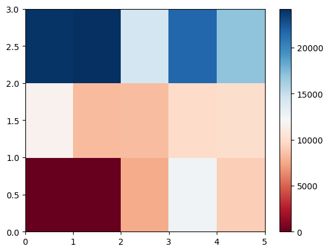

```python
#use the grouped results
plt.pcolor(grouped_pivot, cmap='RdBu')
plt.colorbar()
plt.show()
```

The heatmap plots the target variable (price) proportional to colour with respect to the variables `drive-wheel` and `body-style` on the vertical and horizontal axis, respectively. This allows us to visualize how the price is related to `drive-wheel` and `body-style`.

The default labels convey no useful information to us. Let's change that:

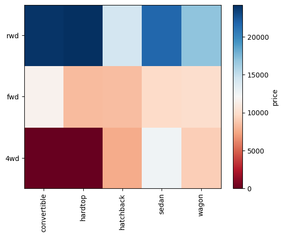

```python
fig, ax = plt.subplots()
im = ax.pcolor(grouped_pivot, cmap='RdBu')

#label names
row_labels = grouped_pivot.columns.levels[1]
col_labels = grouped_pivot.index

#move ticks and labels to the center
ax.set_xticks(np.arange(grouped_pivot.shape[1]) + 0.5, minor=False)
ax.set_yticks(np.arange(grouped_pivot.shape[0]) + 0.5, minor=False)

#insert labels
ax.set_xticklabels(row_labels, minor=False)
ax.set_yticklabels(col_labels, minor=False)

#rotate label if too long
plt.xticks(rotation=90)

fig.colorbar(im, label="price")
plt.show()
```

The main question we want to answer in this module is, "What are the main characteristics which have the most impact on the car price?".

To get a better measure of the important characteristics, we look at the correlation of these variables with the car price. In other words: how is the car price dependent on this variable?

### Correlation and Causation

**Correlation**: a measure of the extent of interdependence between variables.

**Causation**: the relationship between cause and effect between two variables.

It is important to know the difference between these two. Correlation does not imply causation. Determining correlation is much simpler then determining causation as causation may require independent experimentation.

**Pearson Correlation**

The Pearson Correlation measures the linear dependence between two variables `X` and `Y`.

The resulting coefficient is a value between `-1` and `1` inclusive, where:

- `1`: Perfect positive linear correlation.
- `0`: No linear correlation, the two variables most likely do not affect each other.
- `-1`: Perfect negative linear correlation.

Pearson Correlation is the default method of the function `corr`. Like before, we can calculate the Pearson Correlation of the `int64` or `float64` variables.

Sometimes we would like to know the significant of the correlation estimate.

**P-value**

What is this P-value? The P-value is the probability value that the correlation between these two variables is statistically significant. Normally, we choose a significance level of 0.05, which means that we are 95% confident that the correlation between the variables is significant.

```python
#We can obtain this information using "stats" module in the "scipy" library.
from scipy import stats
```

**Wheel-Base vs. Price**

```python
# Let's calculate the Pearson Correlation Coefficient and P-value of 'wheel-base' and 'price'.
pearson_coef, p_value = stats.pearsonr(df['wheel-base'], df['price'])
print("The Pearson Correlation Coefficient is", pearson_coef, " with a P-value of P =", p_value)
```

```
The Pearson Correlation Coefficient is 0.5846418222655081  with a P-value of P = 8.076488270732847e-20
```

Since the p-value is 0.001, the correlation between wheel-base and price is statistically significant, although the linear relationship isn't extremely strong (~0.585).

**Horsepower vs. Price**

```python
# Let's calculate the Pearson Correlation Coefficient and P-value of 'horsepower' and 'price'.
pearson_coef, p_value = stats.pearsonr(df['horsepower'], df['price'])
print("The Pearson Correlation Coefficient is", pearson_coef, " with a P-value of P = ", p_value)
```

```
The Pearson Correlation Coefficient is 0.8096068016571054  with a P-value of P =  6.273536270650361e-48
```

Since the p-value is 0.001, the correlation between horsepower and price is statistically significant, and the linear relationship is quite strong (~0.809, close to 1).

**Length vs. Price**

```python
# Let's calculate the Pearson Correlation Coefficient and P-value of 'length' and 'price'.
pearson_coef, p_value = stats.pearsonr(df['length'], df['price'])
print("The Pearson Correlation Coefficient is", pearson_coef, " with a P-value of P = ", p_value)
```

```
The Pearson Correlation Coefficient is 0.690628380448364  with a P-value of P =  8.016477466158899e-30
```

Since the p-value is 0.001, the correlation between length and price is statistically significant, and the linear relationship is moderately strong (~0.691).

**Engine-Size vs. Price**

```python
pearson_coef, p_value = stats.pearsonr(df['engine-size'], df['price'])
print("The Pearson Correlation Coefficient is", pearson_coef, " with a P-value of P =", p_value)
```

```
The Pearson Correlation Coefficient is 0.8723351674455185  with a P-value of P = 9.26549162219869e-64
```

Since the p-value is 0.001, the correlation between engine-size and price is statistically significant, and the linear relationship is very strong (~0.872).

**Bore vs. Price**

```python
pearson_coef, p_value = stats.pearsonr(df['bore'], df['price'])
print("The Pearson Correlation Coefficient is", pearson_coef, " with a P-value of P =  ", p_value )
```

```
The Pearson Correlation Coefficient is 0.5431553832626603  with a P-value of P =   8.049189483935274e-17
```

**City-mpg vs. Price**

```python
pearson_coef, p_value = stats.pearsonr(df['city-mpg'], df['price'])
print("The Pearson Correlation Coefficient is", pearson_coef, " with a P-value of P = ", p_value)
```

```
The Pearson Correlation Coefficient is -0.6865710067844679  with a P-value of P =  2.3211320655675065e-29
```

Since the p-value is 0.001, the correlation between city-mpg and price is statistically significant, and the coefficient of about -0.687 shows that the relationship is negative and moderately strong.

**Highway-mpg vs. Price**

```python
pearson_coef, p_value = stats.pearsonr(df['highway-mpg'], df['price'])
print( "The Pearson Correlation Coefficient is", pearson_coef, " with a P-value of P = ", p_value )
```

```
The Pearson Correlation Coefficient is -0.7046922650589529  with a P-value of P =  1.7495471144476634e-31
```

Since the p-value is < 0.001, the correlation between highway-mpg and price is statistically significant, and the coefficient of about -0.705 shows that the relationship is negative and moderately strong.

### Conclusion: Important Variables

We now have a better idea of what our data looks like and which variables are important to take into account when predicting the car price. We have narrowed it down to the following variables:

Continuous numerical variables:

- Length
- Width
- Curb-weight
- Engine-size
- Horsepower
- City-mpg
- Highway-mpg
- Wheel-base
- Bore

Categorical variables:

- Drive-wheels

As we now move into building machine learning models to automate our analysis, feeding the model with variables that meaningfully affect our target variable will improve our model's prediction performance.